# Gov 50 Final Project

My final project for Gov 50

Edona Cosovic

## Project thoughts

Final Report: Immigration and Crime

Introduction The central question I would like to investigate is what kind of effect do asylum seekers have with arrests in 2023? In this study, I take two data sets that have data within the time frame January 2023 to June 2023. The first data set explores the number of arrests carried out by the NYPD. The second data set explores the number of asylum reports initiated by the United States Department of Homeland Security. With this data, I explore the relationship between Arrests and Asylum Reports. I hypothesized that there is going to be an increased number of arrests made in conjunction with asylum reports. This is because I expect that in big cities like NYC that bear the brunt of asylum seekers, there could be a shift in public sentiment about the local government’s policy and thus more people committing crimes. With this, it would be interesing to see the crime fluctuations as a result of NYC’s constant commitment to immigrants (via sanctuary city status).

Data I have two data sets received from two different sources. The first is data I retrieved from the Department of Homeland Security and Department of Justice in regards to Asylum Processing Rule Cohort Reports from January to June of 2023. The second data I retrieved from the New York Police Department regarding the arrests in the same period of time.

The Asylum Processing Rule Cohort Reports data that I used combined all the “Credible Fear Claim Outcomes” which essentially means people that stated that they were claiming asylum as a result of credible fears. Thus, you will see that the both positive and negative fear claims were recorded. The data was recorded from the information they gathered from judges and courts in order to probably gain insights on the outcomes of these credible fear claims, which is also likely designed to discourage fraudulent asylum claims. However, this information can importantly be used to determine the general trend of asylum seekers/credible immigration seekers into the US.

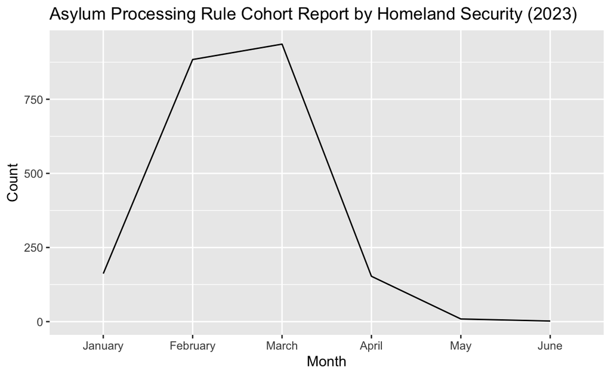

```r
library(ggplot2)
library(dplyr)
library(tidyr)

data <- read.csv("2023_plcy_asylum-processing-rule-cohort-report_fy2023_july.csv")

data_long <- data %>%
  gather(key = "Month", value = "Count", -Asylum.Processing.Rule.Cohort.Report..Outcome.Summary)

outcome_data <- data_long %>%
  filter(Asylum.Processing.Rule.Cohort.Report..Outcome.Summary == "AMI-Eligible Credible Fear Claim Outcomes")

month_mapping <- c("Jan.23" = "January", "Feb.23" = "February", "Mar.23" = "March", "Apr.23" = "April", "May.23" = "May", "Jun.23" = "June")

outcome_data$Month <- factor(outcome_data$Month, levels = colnames(data)[-1])

outcome_data$Month <- month_mapping[outcome_data$Month]

outcome_data <- outcome_data %>% filter(Month %in% c("January", "February", "March", "April", "May", "June"))

outcome_data$Count <- as.numeric(outcome_data$Count)

outcome_data$Month <- factor(outcome_data$Month, levels = c("January", "February", "March", "April", "May", "June"))

plot <- ggplot(data = outcome_data, aes(x = Month, y = Count, group = 1)) +
  geom_line() +
  labs(title = "Asylum Processing Rule Cohort Report by Homeland Security (2023)", x = "Month", y = "Count")

print(plot)
```

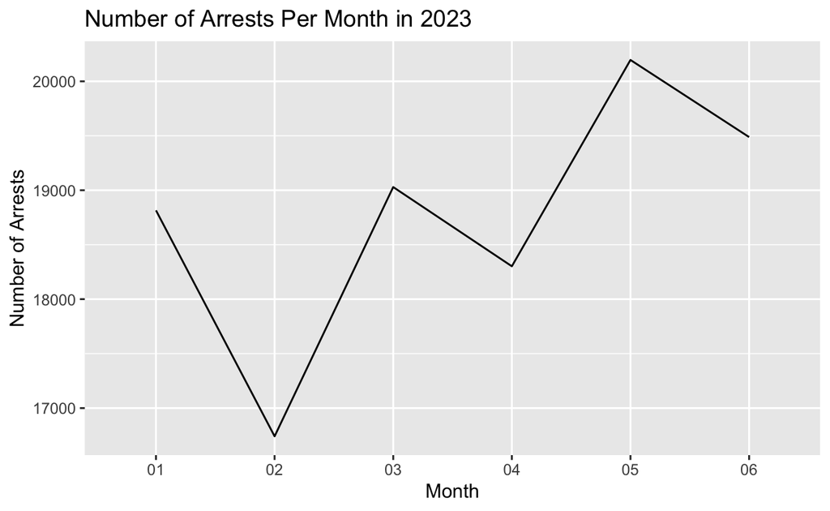

```r
library(ggplot2)
library(dplyr)
library(lubridate)

arrests_data <- read.csv("NYPD_Arrest_Data__Year_to_Date__20231103.csv")
arrests_data$ARREST_DATE <- order(mdy(arrests_data$ARREST_DATE))

arrests_data <- read.csv("NYPD_Arrest_Data__Year_to_Date__20231103.csv")

arrests_data$Date <- as.Date(arrests_data$ARREST_DATE, format = "%m/%d/%Y")

arrests_data$Year <- format(arrests_data$Date, "%Y")
arrests_data$Month <- format(arrests_data$Date, "%m")

arrests_data_2023 <- filter(arrests_data, Year == "2023")

monthly_counts <- table(arrests_data_2023$Month)

monthly_counts_df <- data.frame(Month = as.character(names(monthly_counts)), Count = as.numeric(monthly_counts))

monthly_counts_df$Month <- factor(monthly_counts_df$Month, levels = sprintf("%02d", 1:12))

plot <- ggplot(data = monthly_counts_df, aes(x = Month, y = Count, group = 1)) +
  geom_line() +
  labs(title = "Number of Arrests Per Month in 2023", x = "Month", y = "Number of Arrests")
print(plot)
```

The outcome variable (Y) would be the number of filed asylum reports. The predictor variable (X) would be the number of arrests within the same period. By conducting a regression analysis of the amount of arrests made by the NYPD across this period, the results would give us insight on the impact of these asylum seekers on law enforcement activities in NYC, and possibly support for my hypothesis. The pattern that would support my hypothesis is if there was some positive correlation where with an increase in the number of asylum reports would lead to an increase in arrests.

Results

```r
library(ggplot2)
library(knitr)

monthly_counts_df$Month <- format(as.Date(paste("2023", monthly_counts_df$Month, "01", sep = "-")), "%B")
combined_data <- merge(monthly_counts_df, outcome_data, by = "Month", all = TRUE)

sum(is.na(combined_data$Count.x))
```

```
[1] 0
```

```r
sum(is.na(combined_data$Count.y))
```

```
[1] 0
```

```r
combined_data$Count.x[is.na(combined_data$Count.x)] <- mean(combined_data$Count.x, na.rm = TRUE)
combined_data$Count.y[is.na(combined_data$Count.y)] <- mean(combined_data$Count.y, na.rm = TRUE)

combined_data <- combined_data[complete.cases(combined_data$Count.x, combined_data$Count.y), ]

regression_model <- lm(Count.y ~ Count.x, data = combined_data, na.action = na.exclude)

summary_table <- summary(regression_model)$coefficients
summary_table <- as.data.frame(summary_table)

kable(summary_table, format = "html", caption = "Regression Results")
```

Table 1: Regression Results

|  | Estimate | Std. Error | t value | Pr(>\|t\|) |
| --- | --- | --- | --- | --- |
| (Intercept) | 4630.8214631 | 2711.4758438 | 1.707860 | 0.1628484 |
| Count.x | -0.2277578 | 0.1442835 | -1.578544 | 0.1895828 |

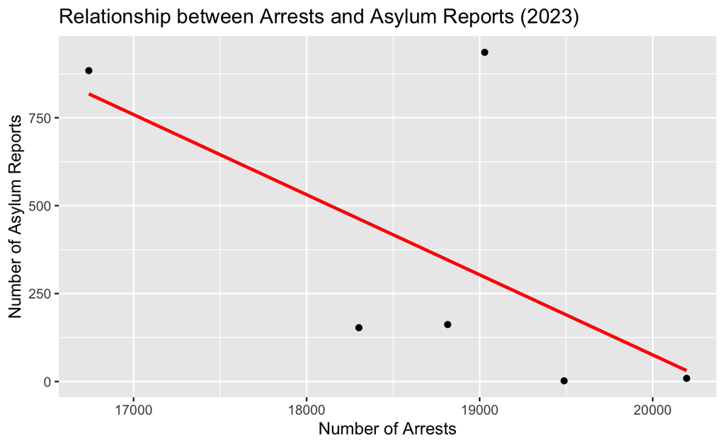

```r
scatter_plot <- ggplot(data = combined_data, aes(x = Count.x, y = Count.y)) +
  geom_point() +
  geom_smooth(method = "lm", se = FALSE, color = "red") +
  labs(title = "Relationship between Arrests and Asylum Reports (2023)", x = "Number of Arrests", y = "Number of Asylum Reports")

print(scatter_plot)
```

The graph above shows a linear regression discussing the relationship between the number of arrests and asylum reports in the same 6-month period. This relationship as per the graph displays a negative correlation where as the number of arrests increases, the number of asylum report cases tends to decrease, and vice versa. Thus, my hypothesis was not necessarily correct.

I conducted a cross sectional analysis of the two variables. The p-value associated with the number of arrests is 0.190. Due to the fact that it is greater than 0.05, the coefficient is not statistically significant. Thus, we should be pretty cautious regarding our ability to interpret the causality between the relationship of the two variables. Thus, this suggests that the relationship between the x and y variables can be due to random chance rather than some relationship between the two.

Conclusion In conclusion, my data might imply some negative correlation between the number of arrests and number of asylum reports– while arrests increase, the number of processed asylum reports decrease – but the results are statistically insignificant. Thus, we cannot assume that there is any causal relationship and be wary to take this correlation as true. Instead, we should opt for some more data to test the statistical significance of that information. This information does not support my hypothesis, but it doesn’t mean that it is necessarily incorrect – there’s just not information to make a solid conclusion on it right now.

However, there are some significant limitations in my data regarding the time frame. Due to the datasets being limited in terms of scope over time as well as not both being in NYC, this case-specific negative correlation cannot simply imply causation. This negative slope is merely suggesting that there is a case-specific statistical tendence for the two variables to move in opposite directions. Other reasons that could be skewing this is attempts to reduce crime have been heightened in NYC while asylum cases remain relatively unaffected – skewing the results. To fix this, I could try to have more data points by using a wider time range and maybe try to find more numbers regarding immigration trends in NYC specifically rather than asylum cases processed federally. Thus, there could be complex other factors impacting the data. Due to the fact that it only includes data from the last 6 months, we can see that the data is pretty limited and current events on crime deterrence efforts can be skewing the data. By finding more data points, we can see if this relationship is moreso geared towards randomness or underlying relationship. Additionally, if I found asylum cases strictly done in the New York City region, that would increase the accuracy of the results even more.

If I had more time to do this project, I would definitely try to compile data from the last 5 years in order to account for variations as a result of COVID and the last year and a half that is still recovering from COVID (crime-wise). Moreover, I would spend much more time trying to find more accurate numbers on recent immigration numbers, since that’s much harder to find than the arrest data. I would possibly email immigration judges in the NYC region to find this information for the sake of making more accurate conclusions.